# Project 1 - Xiaowo Sun

The inauguration of the President of the United States is a ceremony to mark the commencement of a new four-year term of a president of the United States. This ceremony takes place for each new presidential term, even if the president is continuing in office for a second term.

Newly sworn-in presidents usually give a speech referred to as an inaugural address. As with many inaugural customs, this one was started by George Washington in 1789.

Most presidents use their inaugural address to present their vision of America and to set forth their goals for the nation. Some of the most eloquent and powerful speeches are still quoted today.

This notebook will show you some findings in presidents’ inaugural addresses (hope you find they are interesting), from the perspectives of political parties and single speeches.

# Pre-work

```r
packages.used=c("SnowballC", "ggplot2", "rvest", "tibble", "qdap",
                "sentimentr", "gplots", "dplyr", "tm", "syuzhet",
                "factoextra", "scales", "RColorBrewer", "RANN", "tm",
                "topicmodels","NLP","openNLP","magrittr","wordcloud",
                "tidytext","stringr","data.table","shiny","XML","RCurl")
# check packages that need to be installed.
packages.needed=setdiff(packages.used,
                        intersect(installed.packages()[,1],
                                  packages.used))
# install additional packages
if(length(packages.needed)>0){
  install.packages(packages.needed, dependencies = TRUE)
}
# load packages
library(SnowballC)
library(dplyr)
library(rvest)
library(tibble)
library(qdap)
library(sentimentr)
library(gplots)
library(ggplot2)
library(syuzhet)
library(factoextra)
library(scales)
library(RColorBrewer)
library(RANN)
library(tm)
library(topicmodels)
library(NLP)
library(openNLP)
library(magrittr)
library(wordcloud)
library(tidytext)
library(stringr)
library(shiny)
library(data.table)
library(XML)
library(RCurl)
```

This notebook was prepared with the following environmental settings.

```r
print(R.version)
```

```
               _
platform       x86_64-apple-darwin13.4.0
arch           x86_64
os             darwin13.4.0
system         x86_64, darwin13.4.0
status
major          3
minor          3.1
year           2016
month          06
day            21
svn rev        70800
language       R
version.string R version 3.3.1 (2016-06-21)
nickname       Bug in Your Hair
```

# Part 1: From the Perspective of Political Parties – Republican vs. Democratic

Throughout most of its history, politics of the United States have been dominated by political parties. Since the 1860s, these two main parties have been the Republican Party and the Democratic Party. Here, we will look into and talk about the presidents’ inaugural speeches of these two parties.

## 1.1 Load Speeches

```r
##Republican corpus
Rpbl.txt <- file.path("../data/InauguralSpeeches/Republican")
Rpbl <- Corpus(DirSource(Rpbl.txt))
Rpbl
```

```
<<VCorpus>>
Metadata:  corpus specific: 0, document level (indexed): 0
Content:  documents: 24
```

```r
##Democratic corpus
Dmcr.txt <- file.path("../data/InauguralSpeeches/Democratic")
Dmcr <- Corpus(DirSource(Dmcr.txt))
Dmcr
```

```
<<VCorpus>>
Metadata:  corpus specific: 0, document level (indexed): 0
Content:  documents: 22
```

## 1.2 Words Frequency

### Overview – Using Wordcloud

To gain an general sense of the words used, I first use the (`wordcloud`). From wordcloud, we can see that, throughout the history, the two parties used similar words in inaugural speeches simply in terms of the high frequecies of several common words, which are *will*, *people*, *government*, *can*, *must*, etc. And there are only a few words that show a little bit difference. We shall explore further to see more about that.

#### – Republican

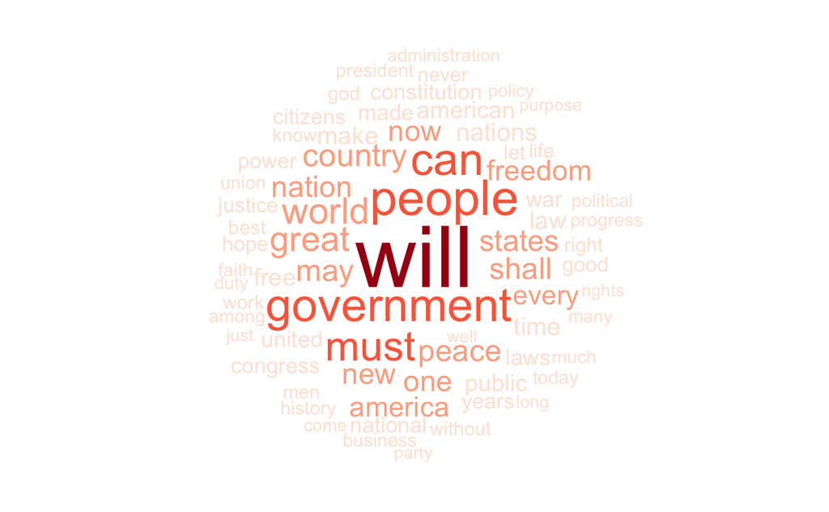

```r
#pre-processing
Rpbl <- tm_map(Rpbl, removePunctuation)
Rpbl <- tm_map(Rpbl, removeNumbers)
Rpbl <- tm_map(Rpbl, tolower)
Rpbl <- tm_map(Rpbl, removeWords, stopwords("english"))
Rpbl <- tm_map(Rpbl, removeWords, c("upon"))
Rpbl <- tm_map(Rpbl, stemDocument)
Rpbl <- tm_map(Rpbl, stripWhitespace)
Rpbl <- tm_map(Rpbl, PlainTextDocument)
tdm.Rpbl <- TermDocumentMatrix(Rpbl)
tdm.tidyRpbl=tidy(tdm.Rpbl)
tdm.overallRpbl=summarise(group_by(tdm.tidyRpbl, term), sum(count))
#generate the wordcloud
wordcloud(tdm.overallRpbl$term, tdm.overallRpbl$`sum(count)`, max.words=70, random.order=FALSE, random.color=FALSE,rot.per=0, colors=brewer.pal(5,"Reds"))
```

#### – Democratic

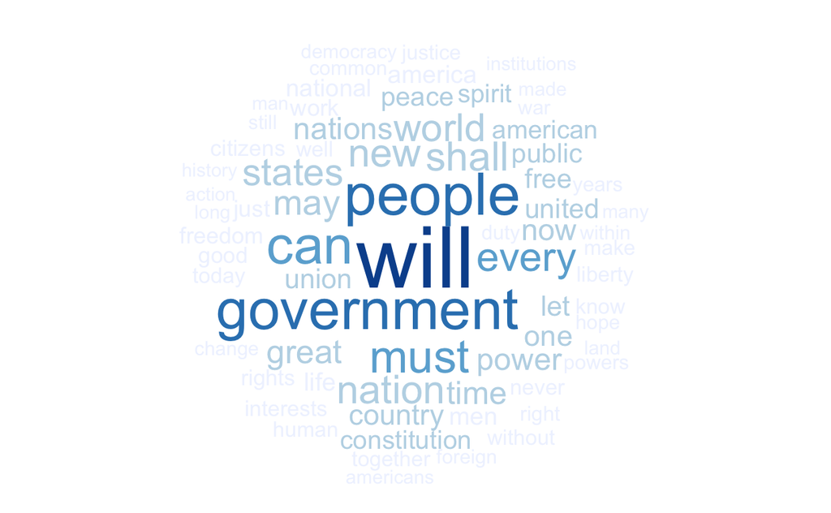

```r
#pre-processing
Dmcr <- tm_map(Dmcr, removePunctuation)
Dmcr <- tm_map(Dmcr, removeNumbers)
Dmcr <- tm_map(Dmcr, tolower)
Dmcr <- tm_map(Dmcr, removeWords, stopwords("english"))
Dmcr <- tm_map(Dmcr, removeWords, c("upon"))
Dmcr <- tm_map(Dmcr, stemDocument)
Dmcr <- tm_map(Dmcr, stripWhitespace)
Dmcr <- tm_map(Dmcr, PlainTextDocument)
tdm.Dmcr <- TermDocumentMatrix(Dmcr)
tdm.tidyDmcr=tidy(tdm.Dmcr)
tdm.overallDmcr=summarise(group_by(tdm.tidyDmcr, term), sum(count))
#generate the wordcloud
wordcloud(tdm.overallDmcr$term, tdm.overallDmcr$`sum(count)`, max.words=70, random.order=FALSE, random.color=FALSE,rot.per=0, colors=brewer.pal(5,"Blues"))
```

### Frequency of Top 30 Words

#### – Republican

```r
dtm.Rpbl <- DocumentTermMatrix(Rpbl)
freq.Rpbl <- colSums(as.matrix(dtm.Rpbl))
length(freq.Rpbl)
```

```
[1] 6596
```

```r
#sort the terms based on frequency in a descending order
ord.Rpbl <- order(freq.Rpbl, decreasing = TRUE)
#view top 30
freq.Rpbl[head(ord.Rpbl, n=30L)]
```

```
      will     people government        can       must      world      great
       489        254        235        227        201        171        159
   country        may      peace      shall     states     nation        new
       139        132        130        129        127        125        123
       one        now    freedom    america      every    nations       time
       123        121        117        114        108         96         94
      make       free        law   american     public     united       laws
        93         91         91         87         87         79         78
       war       made
        78         77
```

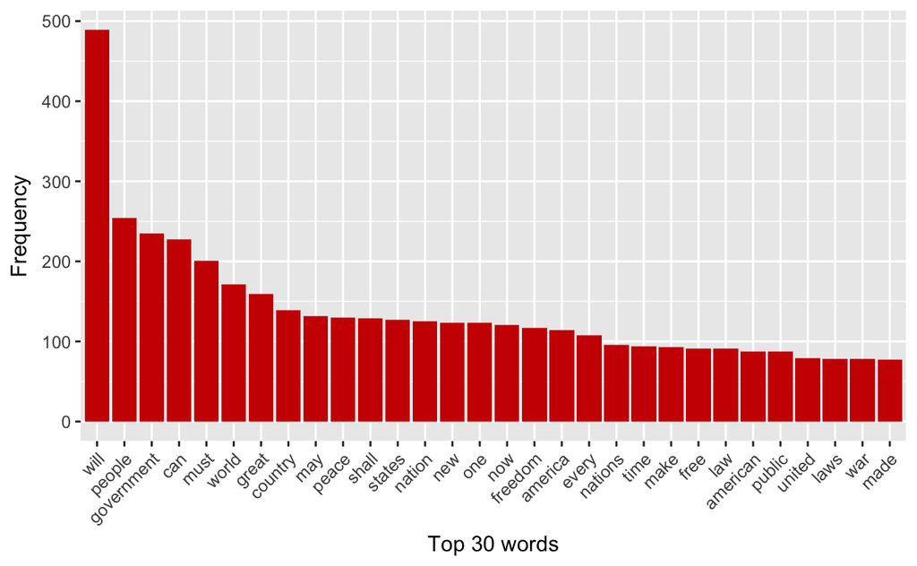

```r
wf.Rpbl <- data.frame(word=names(freq.Rpbl), freq=freq.Rpbl)
p.Rpbl <- ggplot(subset(wf.Rpbl, freq>76), aes(reorder(word, -freq),freq))
p.Rpbl <- p.Rpbl + geom_bar(stat="identity",fill = "red3")
p.Rpbl <- p.Rpbl + theme(axis.text.x=element_text(angle=45, hjust=1))
p.Rpbl <- p.Rpbl + xlab('Top 30 words') + ylab('Frequency')
p.Rpbl
```

#### – Democratic

```r
dtm.Dmcr <- DocumentTermMatrix(Dmcr)
freq.Dmcr <- colSums(as.matrix(dtm.Dmcr))
length(freq.Dmcr)
```

```
[1] 5707
```

```r
#sort the terms based on frequency in a descending order
ord.Dmcr <- order(freq.Dmcr, decreasing = TRUE)
#view top 30
freq.Dmcr[head(ord.Dmcr, n=30L)]
```

```
        will       people   government          can         must        every
         293          188          182          168          139          118
       shall          new       nation        world       states          may
         117          115          114          110          107           97
       great         time        power      nations          now      country
          88           84           80           79           77           72
         one          let        union       united         free       public
          72           68           67           66           65           64
       peace constitution     american       spirit         life      america
          63           60           59           59           57           56
```

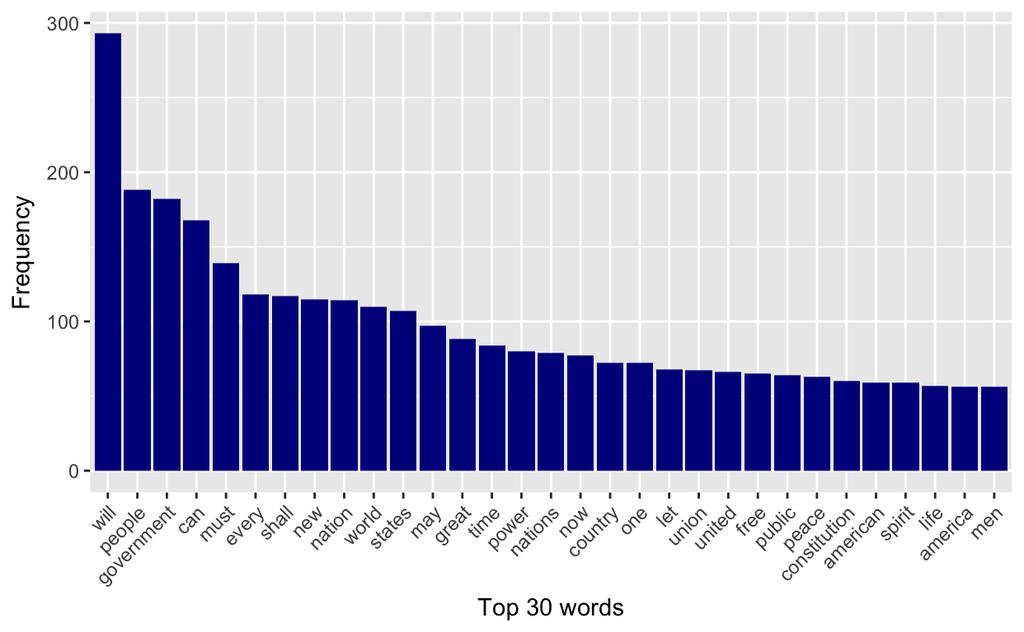

```r
wf.Dmcr <- data.frame(word=names(freq.Dmcr), freq=freq.Dmcr)
p.Dmcr <- ggplot(subset(wf.Dmcr, freq>55), aes(reorder(word, -freq),freq))
p.Dmcr <- p.Dmcr + geom_bar(stat="identity",fill = "blue4")
p.Dmcr <- p.Dmcr + theme(axis.text.x=element_text(angle=45, hjust=1))
p.Dmcr <- p.Dmcr + xlab('Top 30 words') + ylab('Frequency')
p.Dmcr
```

Still, there is not much difference between the words used by two parties. To choose several words describing things that two parties identically pursue or provide, for the Republicans, the words would be *freedom*, *law*, *public*, and for the Democrats, the words would be *power*, *constitution*, *spirit*.

Considering the high frequency of *new*, *great*, *peace*, I irresponsibly guess that presidents were commiting themselves to bringing changes and something great to the nation, and safeguarding the world peace.

# Part 2: From the Perspective of Single Speeches

#### – take Donald Trump as an example

This part, I mainly provide the visualization of the sentiment development, the readability and the memorability of every inaugural speech since 1789.

## 2.1 Load Speeches

```r
folder.pathA="../data/InauguralSpeeches/All"
speeches.A=list.files(path = folder.pathA, pattern = "*.txt")
ff.A<-Corpus(DirSource(folder.pathA))
```

## 2.2 Sentiment Development

Here I apply qdap’s sentiment analysis to speeches. The qdap’s sentiment analysis is based on a sentence-level formula classifying each word as either positive, negative, neutral, negator or amplifier, per [Hu & Liu’s sentiment lexicon](https://www.cs.uic.edu/~liub/FBS/sentiment-analysis.html).

Through the variation, the trendline reveals sentiment along with the increasing positivity in general.

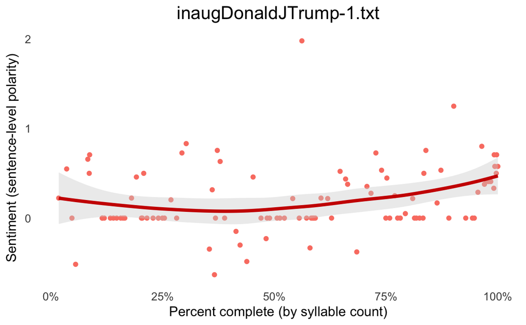

```r
speech.df <- data.table(speech=ff.A[[9]]$content, person=ff.A[[9]]$meta$id)
sentences <- data.table(sentSplit(speech.df, "speech"))
sentences <- sentences[, sentence.num := seq(nrow(sentences))]
sentences <- sentences[, tot := NULL]
setcolorder(sentences, c("person", "sentence.num", "speech"))
#syllables per sentence
sentences <- sentences[, syllables := syllable_sum(speech)]
#add cumulative syllable count and percent complete as proxy for progression
sentences <- sentences[, syllables.cumsum := cumsum(syllables)]
sentences <- sentences[, pct.complete := syllables.cumsum / sum(sentences$syllables)]
sentences <- sentences[, pct.complete.100 := pct.complete * 100]
pol.df <- polarity(sentences$speech)$all
sentences <- sentences[, words := pol.df$wc]
sentences <- sentences[, pol := pol.df$polarity]
#customize and generate plot
my.theme <-
  theme(plot.background = element_blank(),
        panel.grid.major = element_blank(),
        panel.grid.minor = element_blank(),
        panel.border = element_blank(),
        panel.background = element_blank(),
        axis.ticks = element_blank(),
        axis.text=element_text(size=10),
        axis.title=element_text(size=12),
        plot.title=element_text(size=16, hjust=0.5))
Plot.setting <- function(gg)
  return(gg + geom_point(color="salmon") +
           stat_smooth(color="red3", fill="lightgray", size=1.4) +
           xlab("Percent complete (by syllable count)") +
           scale_x_continuous(labels = percent) + my.theme)
Plot.setting(ggplot(sentences, aes(pct.complete, pol)) +
                    ylab("Sentiment (sentence-level polarity)") +
                    ggtitle(ff.A[[9]]$meta$id))
```

## 2.3 Readability

Readability tests are typically based on syllables, words, and sentences in order to approximate the grade level required to comprehend a text. qdap offers several of the most popular formulas, of which I chose the [Automated Readability Index](https://en.wikipedia.org/wiki/Automated_readability_index).

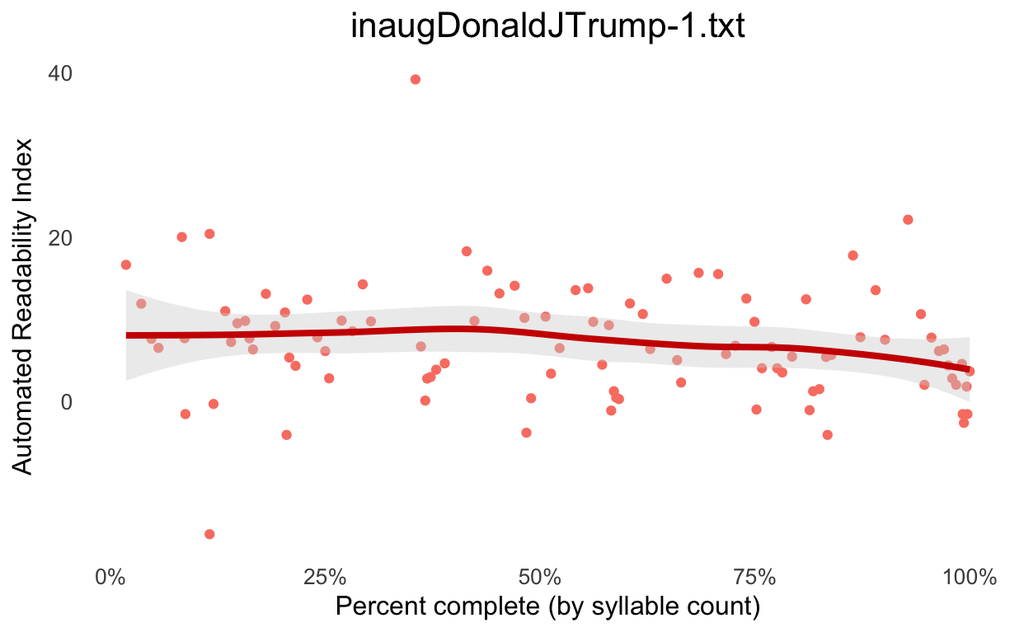

```r
sentences <- sentences[, readability := scores(automated_readability_index(speech,sentence.num, output = "valid"))$Automated_Readability_Index]
Plot.setting(ggplot(sentences, aes(pct.complete, readability)) +
                    ylab("Automated Readability Index") +
                    ggtitle(ff.A[[9]]$meta$id))
```

## 2.4 Memorability

Google search results can serve as a useful indicator of public opinion. I use a function from [theBioBucket’s blog post](http://thebiobucket.blogspot.com/2012/03/playing-with-xml-get-no-of-google.html) to count Google hits for a query. Alert: Google will block you after about the 300th recursion!

```r
#scraping Google search hits
GoogleHits <- function(query){
  require(XML)
  require(RCurl)

  url <- paste0("https://www.google.com/search?q=", gsub(" ", "+", query))

  CAINFO = paste0(system.file(package="RCurl"), "/CurlSSL/ca-bundle.crt")
  script <- getURL(url, followlocation=T, cainfo=CAINFO)
  doc <- htmlParse(script)
  res <- xpathSApply(doc, '//*/div[@id="resultStats"]', xmlValue)
  return(as.numeric(gsub("[^0-9]", "", res)))
}
```

A quick plot reveals that there’s a huge difference between the most-quoted sentences and the rest of the speech, particularly the top ten. Do these top sentences align with your expectations?

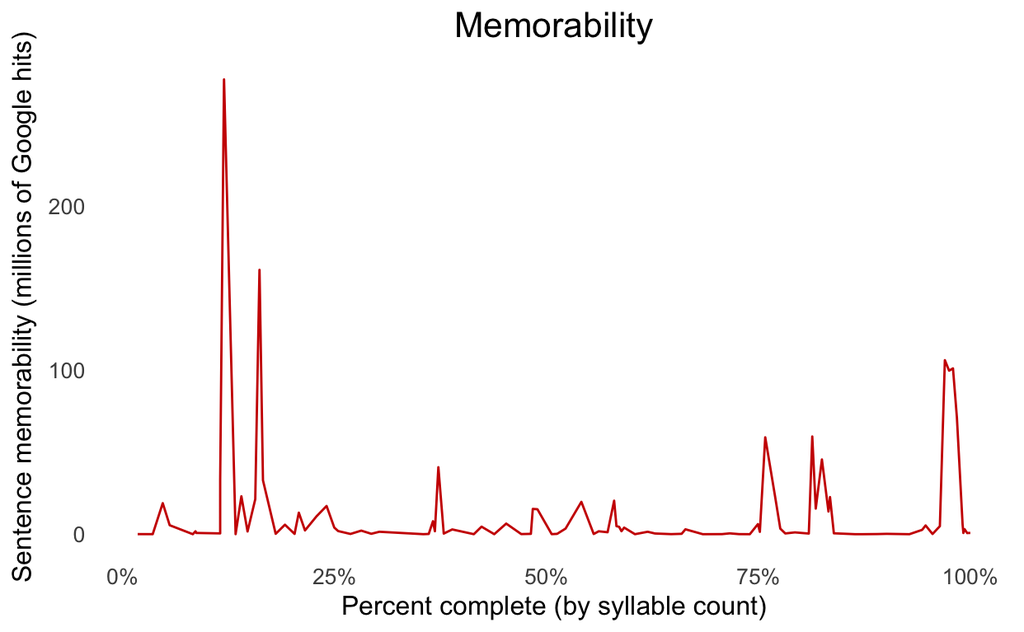

```r
##sometimes this chunk may take long time to run or report an error, if this happens then, please just re-open the Rstudio and try again later
#pass each sentence to the function, stripped of punctuation and grouped in brackets, and with “mlk” added to ensure it related to the speech
sentences[, google.hits := GoogleHits(paste0("[", gsub("[,;!.]", "", speech),
                                             "] mlk"))]
ggplot(sentences, aes(pct.complete, google.hits / 1e6)) +
  geom_line(color="red3") + # Lighten dots
  xlab("Percent complete (by syllable count)") +
  scale_x_continuous(labels = percent) + my.theme +
  ylim(0, max(sentences$google.hits) / 1e6) +
  ylab("Sentence memorability (millions of Google hits)") +
  ggtitle("Memorability")
```

```r
head(sentences[order(-google.hits)]$speech, 10)
```

```
 [1] "and giving it back to you, the people."
 [2] "Their victories have not been your victories."
 [3] "Together, we will make America strong again."
 [4] "We will make America proud again."
 [5] "We will make America wealthy again."
 [6] "We will make America safe again."
 [7] "The time for empty talk is over."
 [8] "We are protected and we will always be protected."
 [9] "Do not allow anyone to tell you that it cannot be done."
[10] "And their success will be our success."
```

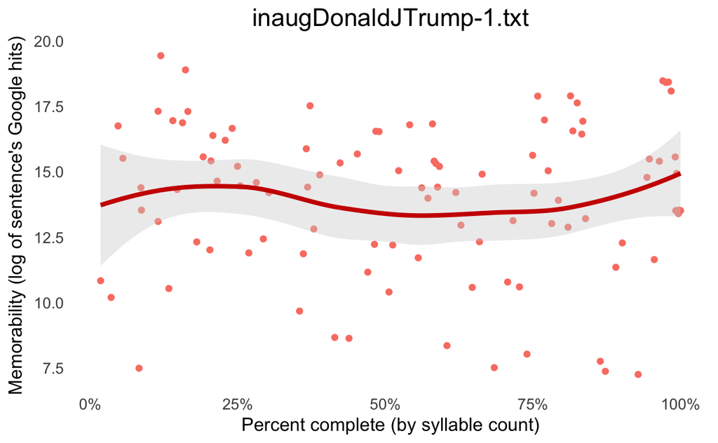

```r
#plotting Google hits on a log scale reduces skew and allows us to work on a ratio scale
sentences <- sentences[, log.google.hits := log(google.hits)]
Plot.setting(ggplot(sentences, aes(pct.complete, log.google.hits)) +
                    ylab("Memorability (log of sentence's Google hits)") +
                    ggtitle(ff.A[[9]]$meta$id))
```

#### Questions:

Which speech is the most memorable and which one is the most forgetable? Which speeches have more sentiment swings? Which speech has the most readable content? ……